# Study of AMR

Interestingly but not surprisingly, the global flows in our model are inversed in comparison with a model including cost of resistance. This is due to the fact that $I_z$ spreads as easily as $I_w$. At the same time, patients infected with $I_w$ do recover more easily than those infected with $I_z$ as $\varepsilon$ increases. Therefore there is a stronger flow from $I_w$ to $S$ than from $I_z$, when the populations are equal.

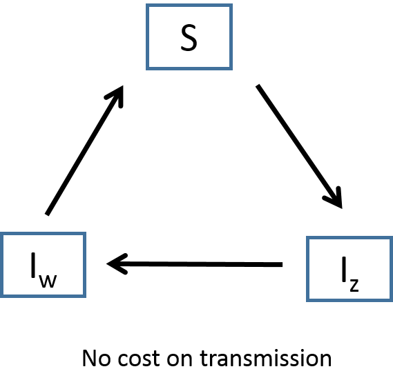

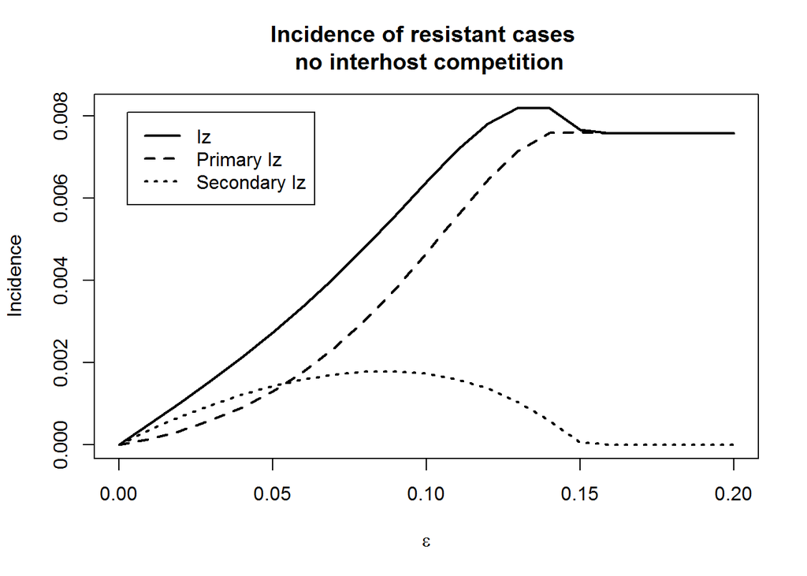

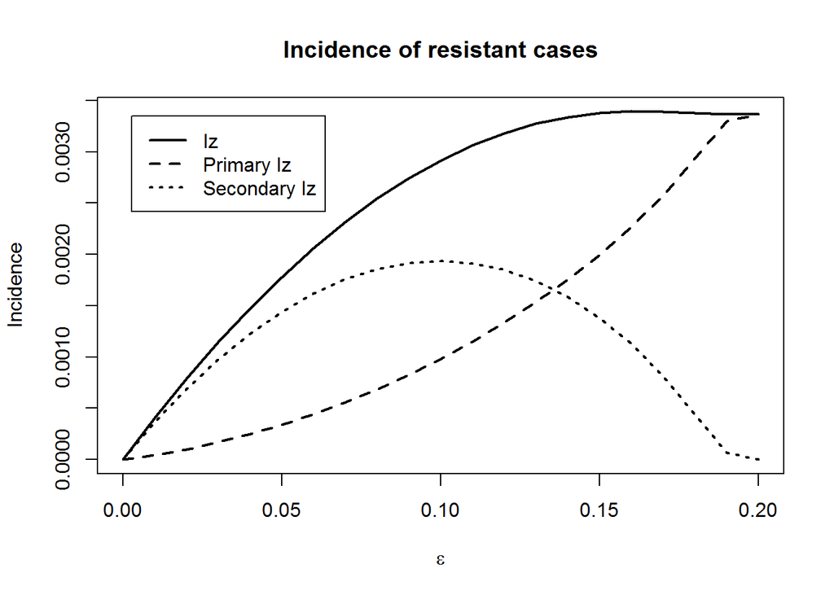

In general, when the transmission cost increases, $i.e.$ the $\beta_z$ decreases while $\beta_w$ remains stable, $I_z$ is fixed and becomes prevalent for higher values of $\varepsilon$.

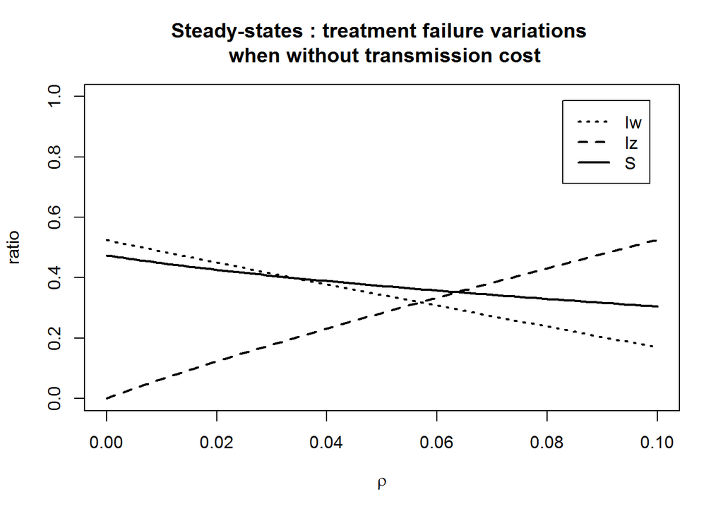

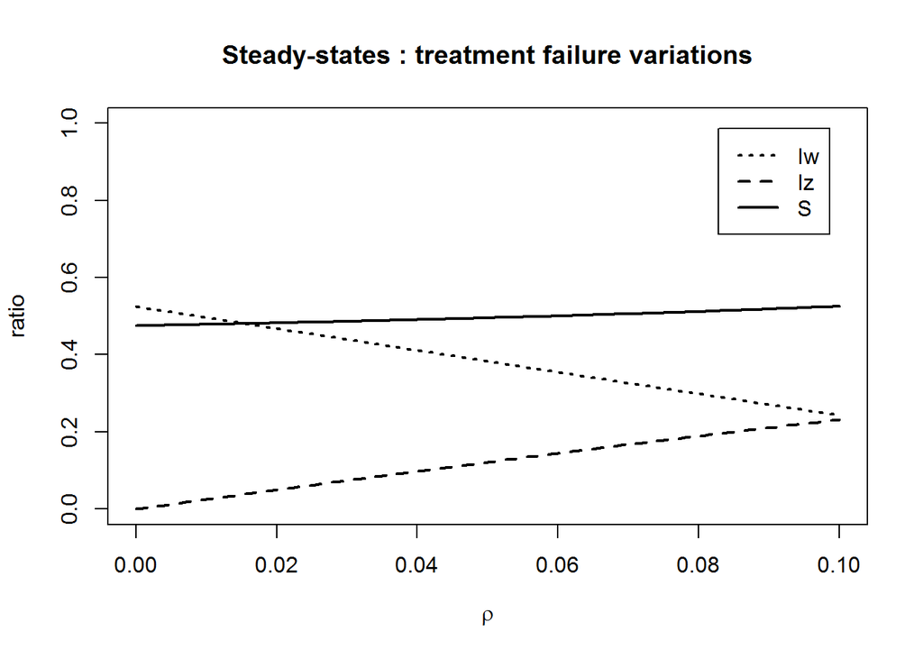

Consistant with the above-mentioned findings, when $\rho=0$, $i.e.$ there is no treatment failure and therefore no secondary resistance, resistant strain cannot coexist.

Moreover unlike in the situation where the transmission cost does exist, the global burden of infection increases with $\rho$. This is due to the fact, that the resistant strain has the behaviour of a sensitive one in antibiotics-free environment. Therefore, at values of $\rho$ incompatible with $I_w$ coexistence ($\rho$>0.15), $I_z$ gains the same levels as $I_w$ in antibiotics-free environment ($I_z$=0.75; data not shown).

## Inhibition of secondary resistance

When only primary resistance is preserved, that is to say $\rho=0$, we observe that the coexistence is very limited (for $\varepsilon$ between 0.27 and 0.29).

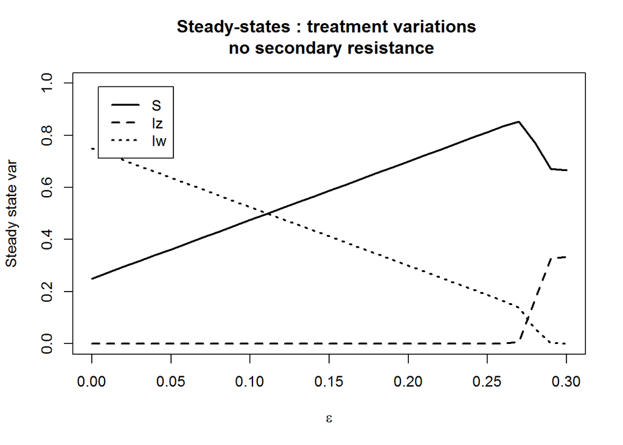

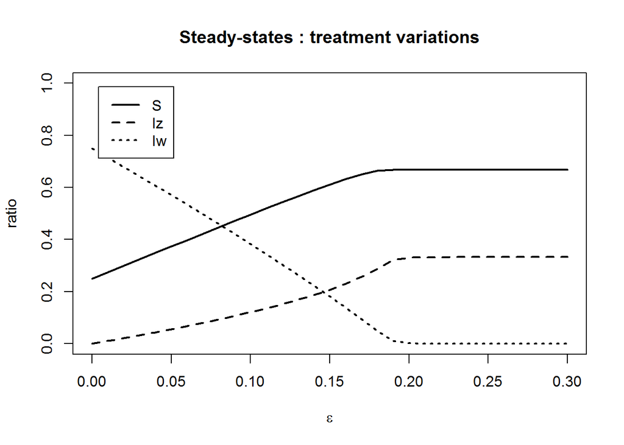

Although the model was started with an important subpopulation of $I_z$ (*cca* 12%), this subpopulation has vanished at steady state, being systematically converted into $I_w$. The stability of $I_z$ subpopulation is therefore substantially dependant on the secondary resistance in long term.

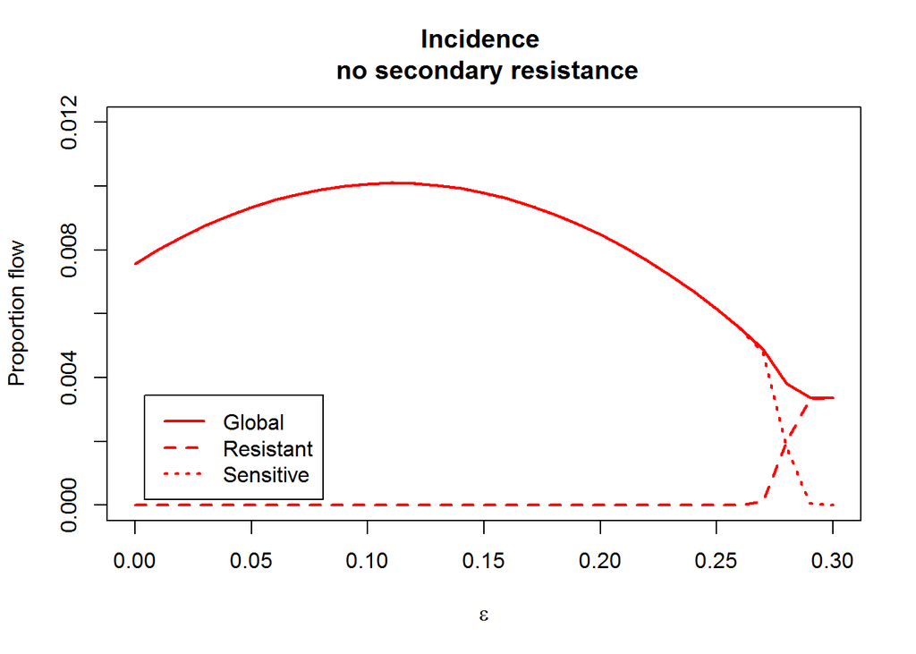

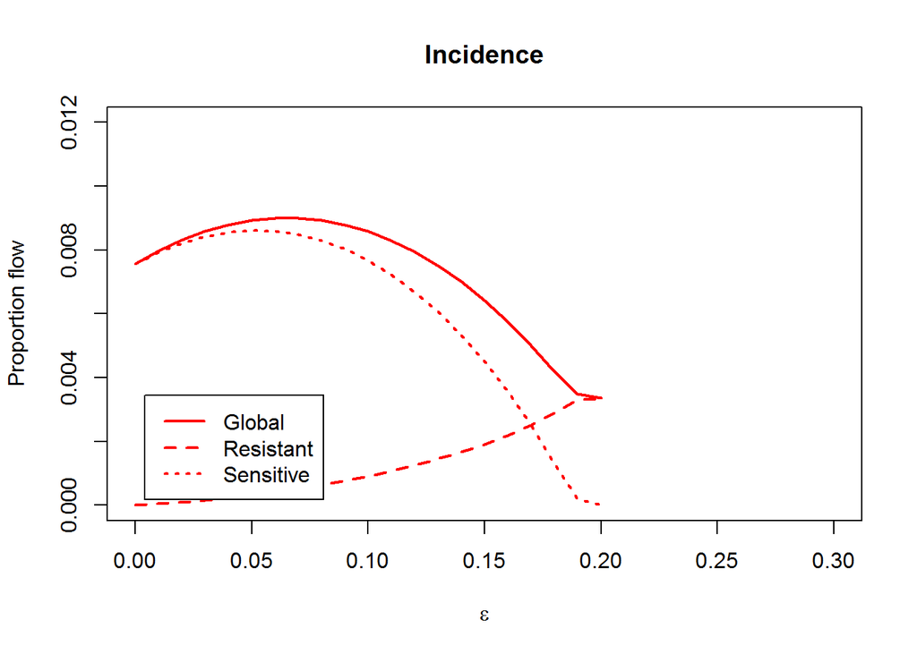

Without secondary resistance, the flows between $I_w$ and $I_z$ reach equilibria when $\beta_w*(1-\varepsilon)=\beta_z*\varepsilon$, that is to say when $\varepsilon=0.73$. The emergence of stable state is therefore rather linked to the upraise of $S$ values due to enhanced treatment than to the inversion of flows between $I_z$ and $I_w$.

## Inhibition of primary resistance

Here, the primary resistance is omitted, $i.e.$ $\beta_z=0$ and the resistant strains cannot be transmitted.

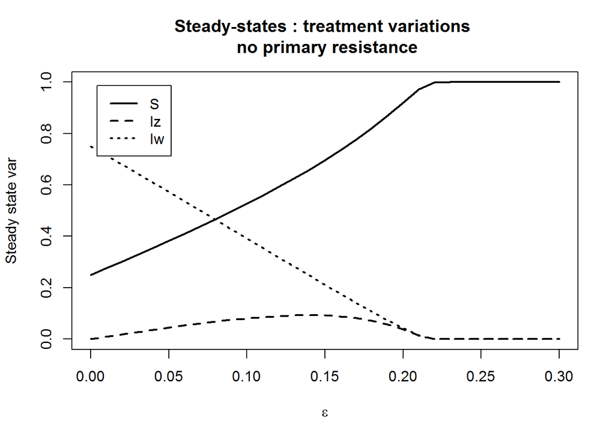

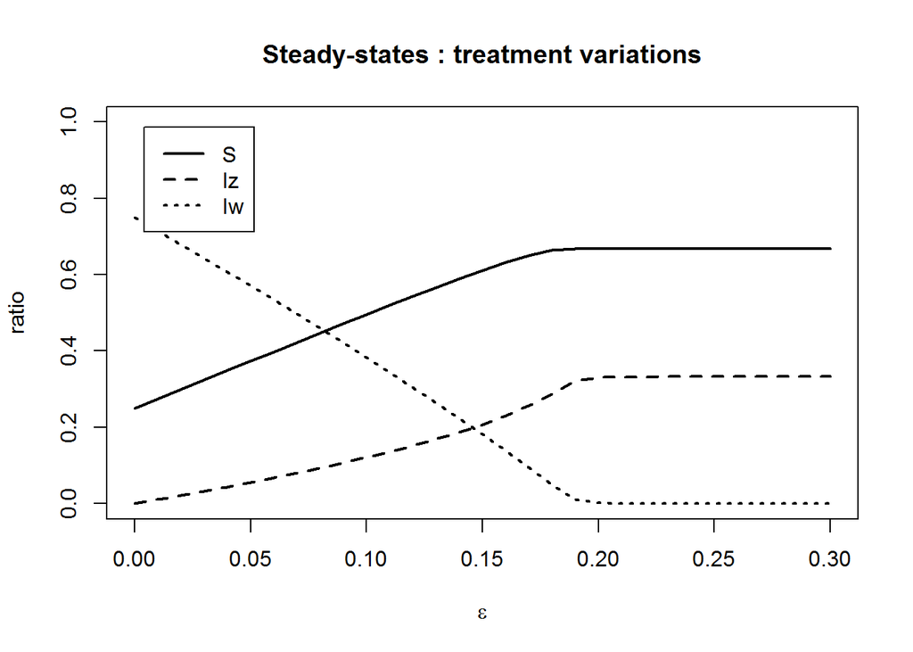

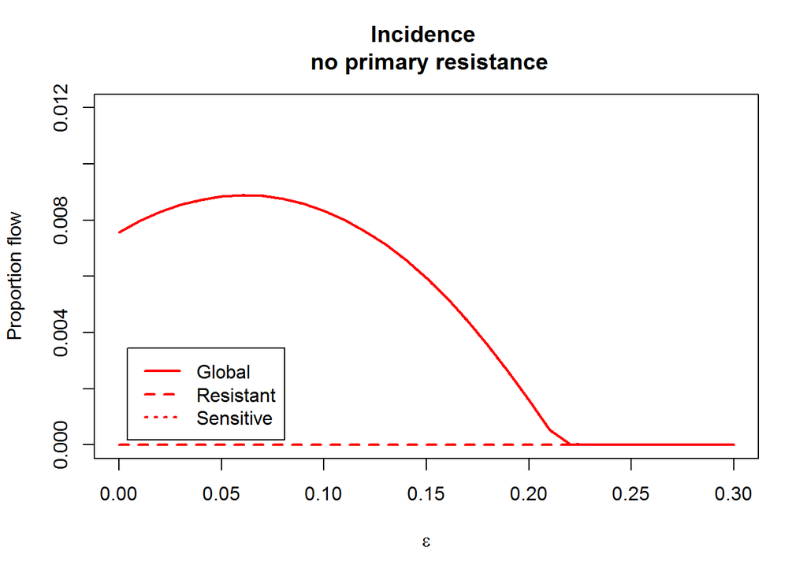

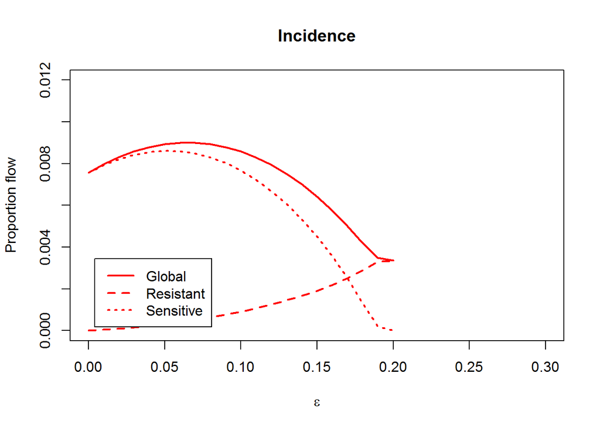

In comparison with a simple model in which only susceptible population and sensitive strains are present, the incidence is smaller for the same $\varepsilon$. This is due to the treatment failures : in fact, the $I_z$ will represent here a dead-end for the pathogen that cannot be transmitted.

# Study of hysteresis

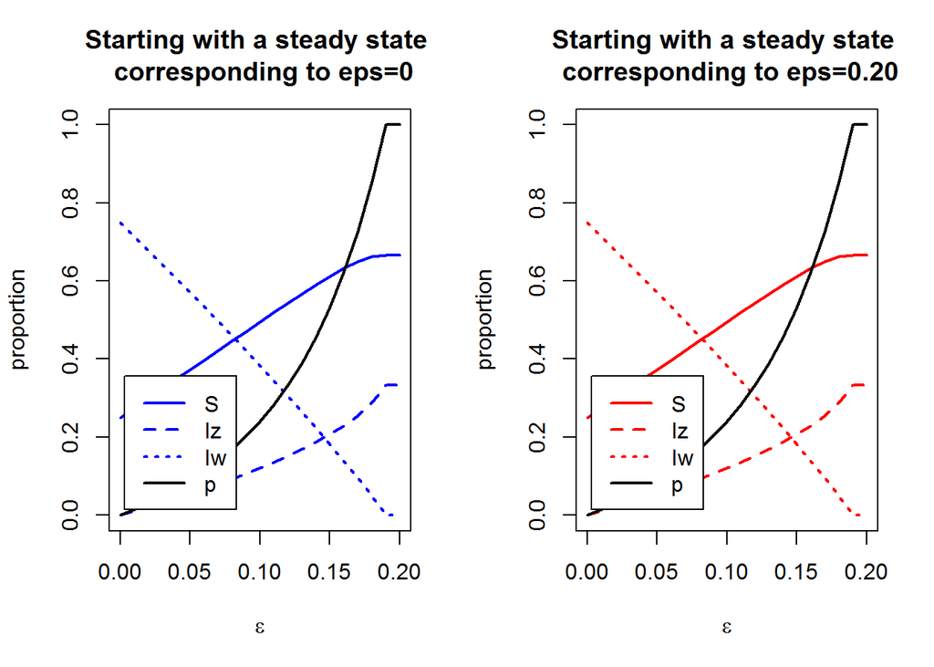

The back and forth pathways being the same, we can say that there is no hysteresis in our model. Therefore, theoretically resistant cases can be diminished by reduced use of antibiotics. The question now is whether the changing $\varepsilon$ has the same effect within the same timespan. This brings us to the study of inertia.

# Study of inertia

## Varying the speed of change of $\varepsilon$

### Linear variations

In this part, we vary rate at which the proportion of patients varies, still considering that the proportion of patients is directly linked to the $AMU$. At first, we start from $\varepsilon$=0 and increase its value up to 1.

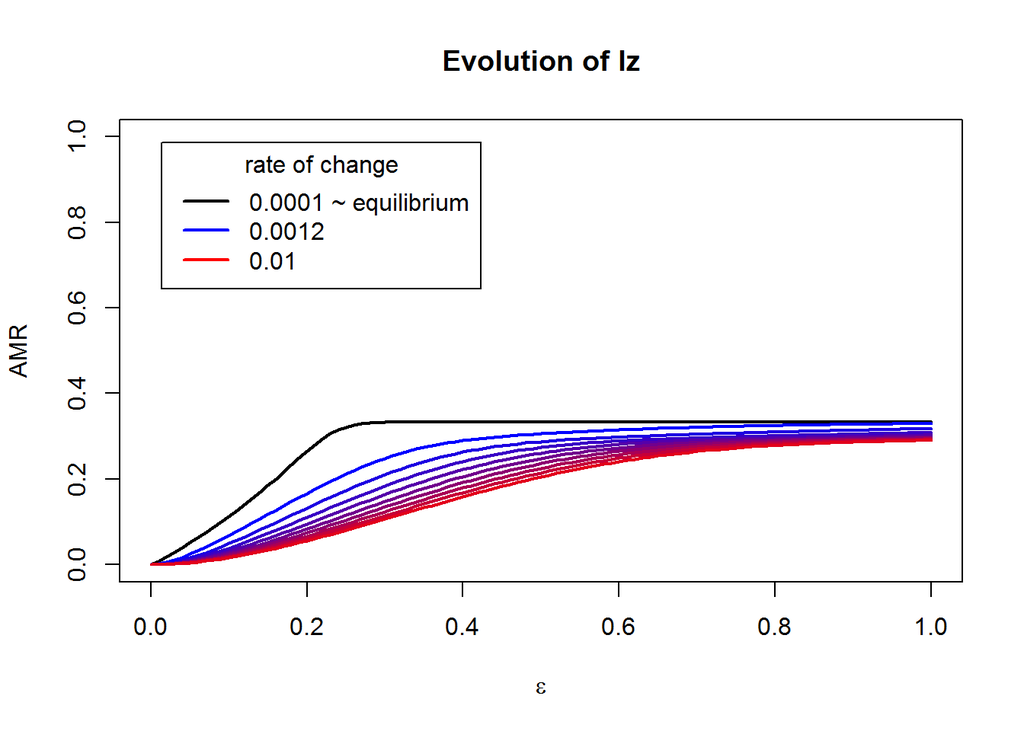

As the rate of change increases, the proportion of $I_z$ is more distant from its steady state value. The rate of change of $\varepsilon$ can thus have a severe impact on the detected resistance level. Presuming that all hospitals are in equilibrium can be a rough simplification.

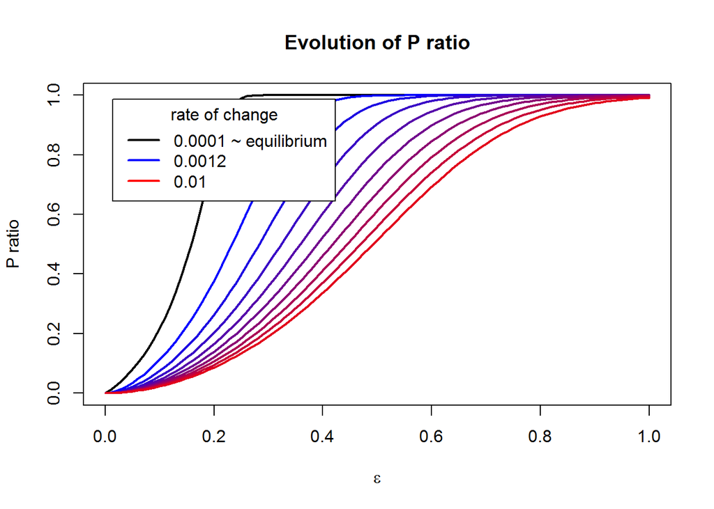

Delay in reaching equilibrium due to rapid increase of $\varepsilon$ can be observed for the P (defined as the ratio between $I_z$ and burden of infection) as well.

### Sinusoidal variations

Another method of grasping the inertia of a model, consists in varying $\varepsilon$ periodically. $\varepsilon$ is here a sine function with a certain pulsation :

$$\varepsilon=A*sin(\omega*t)+B \\$$
Where
$$A=B=(max \varepsilon - min\varepsilon)/2$$
In order to prevent effects of $I_w$ extinction due to high $\varepsilon$, we opted here for 0.00 as the minimum value of $\varepsilon$ and 0.18 as its maximum value.

$$\varepsilon=0.09*sin(\omega*t)+0.09 \\$$

The $\varepsilon$ varies as follows for different values of pulsation $\omega$ (higher pulsations mean faster change in time) :

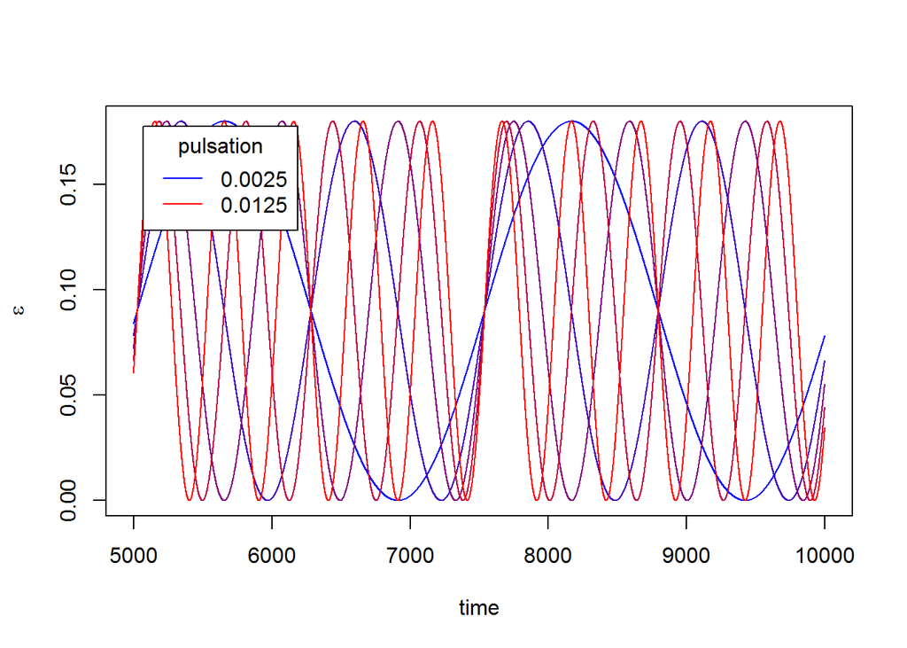

We compare the steady state values of $I_z$ and P to their values while $\varepsilon$ varies periodically with different pulsations:

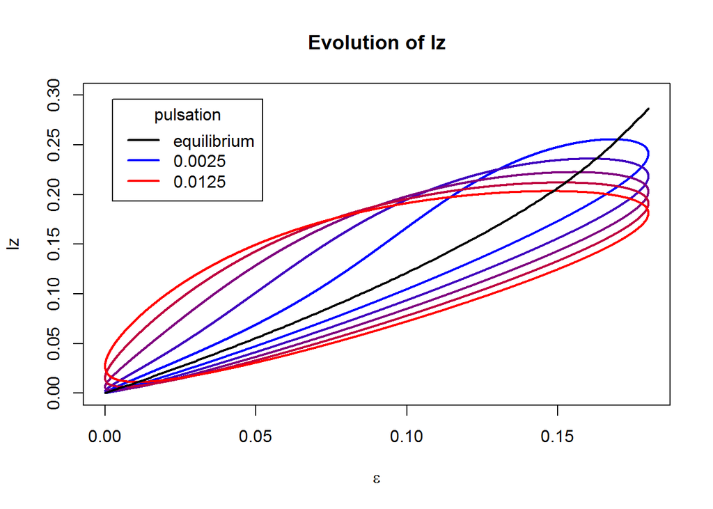

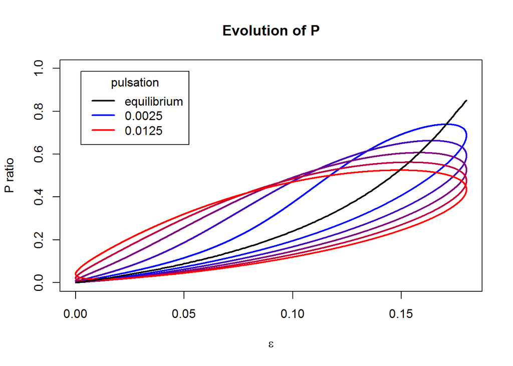

The smaller the pulsations are, and therefore the slower the variation of $\varepsilon$ is, the more the corresponding curve approaches the steady-state curve.

The question is now whether the same times are required for reaching equilibrium (TREs) while increasing or decreasing $\varepsilon$.

## Time to reach equilibrium while increasing or decreasing $\varepsilon$

### Comparing TREs for the same start value of $\varepsilon$

The idea is to compare the number of steps that are required for reaching a steady state while either increasing or decreasing the value of $\varepsilon$.

The model starts at a steady state for a given value of $\varepsilon$. Then the $\varepsilon$ is increased or decreased by certain $\delta$ and the time required for reaching equilibrium (TRE), represented by a value of convergience criterion (here $c$=0.000001). The output is the following comparison of TREs for each starting value of $\varepsilon$:

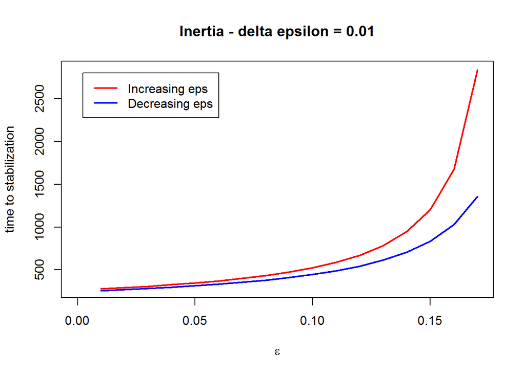

For higher values of $\varepsilon$, when the proportion of treated patients changes, it takes longer time to reach the steady states. The TREs are longer when $\varepsilon$ is increased and the difference between TREs related to increasing and to decreasing $\varepsilon$, increases with initial value of $\varepsilon$.

We consider here only the interval of $\varepsilon$ where both lineages coexist at considerable values, $i.e.$ $I_w$ does not reach an irrescuable 0.

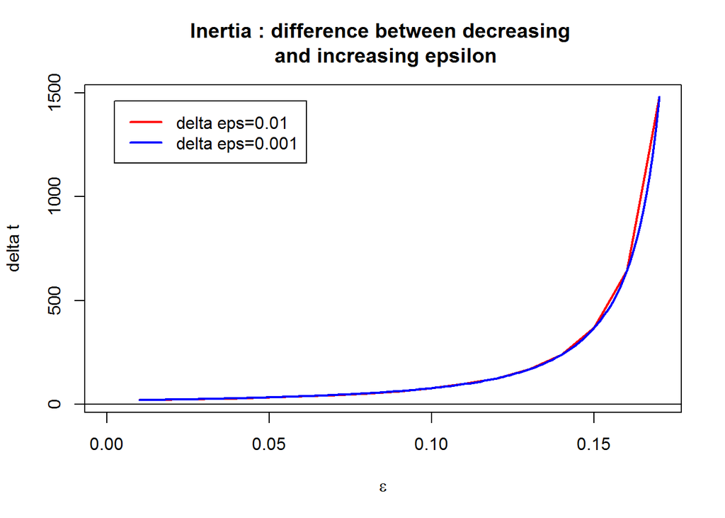

Here, the plot represents the time lapse between reaching equilibrium while decreasing and increasing $\varepsilon$, either with a large or small $\delta$ (0.01 and 0.001). For each value of $\delta$, the time lapse is strictly positive and increases exponentially with the initial value of $\varepsilon$. Therefore, in general the steady states are reached with a bigger delay when the proportion of treated patients is increased than when it is decreased by the same value.

Interestingly, the difference between TREs is the same although the value of $\delta$ differs.

We can compare the differences obtained with different values of $\delta\varepsilon$ (0.01 and 0.001) while using the same metrics such as $\frac{\delta t}{\delta \varepsilon}$ :

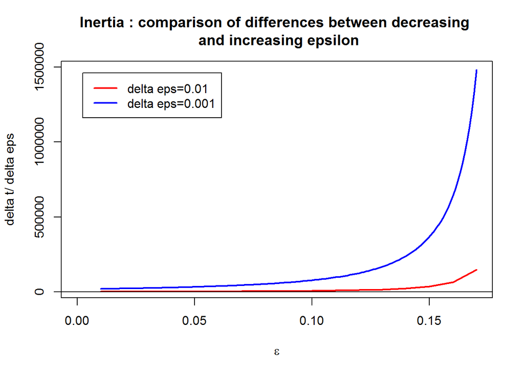

Presumably, when considering the same metrics, the difference between TREs is $circa$ ten times lower when $\delta$ is bigger.

# Detailing $AMU$

## Definitions, understanding $DDD$

In the previous parts, the $AMU$ in the model was assimilated to the proportion of treated patients. In reality, the $AMU$ is reported as defined daily doses ($DDD$) per patient/occupied bed per day. Therefore it is a combination of the treatment duration, concentration of daily doses and the number or proportion of patients.

$DDD/pt/d = \varepsilon*C*t$

In fact, each of these three components may have an impact on the emergence and spread of resistance.

$\varepsilon$ intervenes in the recovery of patients, in the secondary resistance and the outcome of intrahost competition.

Concentration intervenes in the mutation rate enabling resistant mutants to appear and in the selection of the mutant. Several recent papers showed that the outcome of mutant selection depends on the relative position of growth rate curves as the function of drug concentration. The difference between the growth rates of a wild type and mutant strains represents selective coefficient. Its value influences the outcome of selection.

Time of treatment can intervene in the mutation selection. It has been shown that short and long drug administrations have the same efficiency in clearance of sensitive pathogen, while with the length of drug administration, the probability of secondary resistance increases.

We neglige other phenomena that may intervene, such as the heterogeneity in the total pathogen population when drug administration is started (and possible success of “hit hard and early” strategy) or the drug consumption in treatment of other diseases.

In the following parts, we will try to implement a more detailed version of the $AMU$ in the model in order to see the possible impacts of an intrinsic bias linked to the aggregated $AMU$ reports.

For the sake of clarity, we opt to use at first the Drug quantity per patient ($Q$), and consider that it has the same impact as the drug concentration on the outcome of selection. Therefore we have:

$Q = C*t$

The drug quantity used per patient will then have an impact on the mutation rate and the selective coefficient.

## Model with a detailed version of $AMU$

### Impact of $Q$ on mutation rate and selective coefficient

In contrast with our first model, the $AMU$ is not considered as directly linked to the proportion of treated patients, but as a product of proportion of treated patients ($\varepsilon$) and the drug quantity used per patient ($Q$).

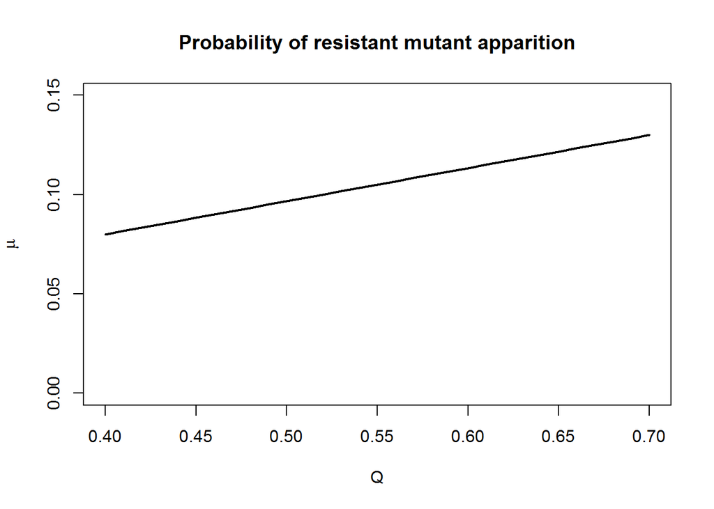

As it has been mentioned above, we consider that the drug quantity has an impact on resistant mutant selection in intrahost dynamics. This impact will depend on the relative position of growth rate curves of mutant and resistant strains.

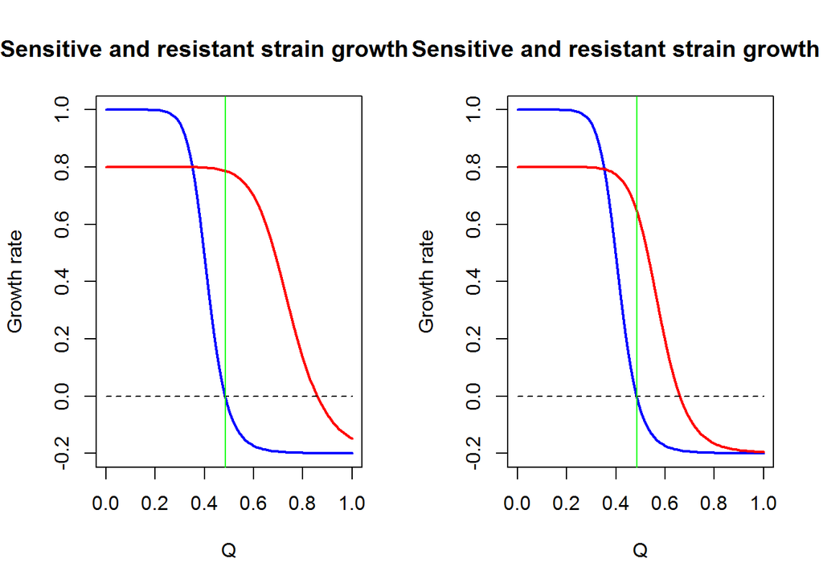

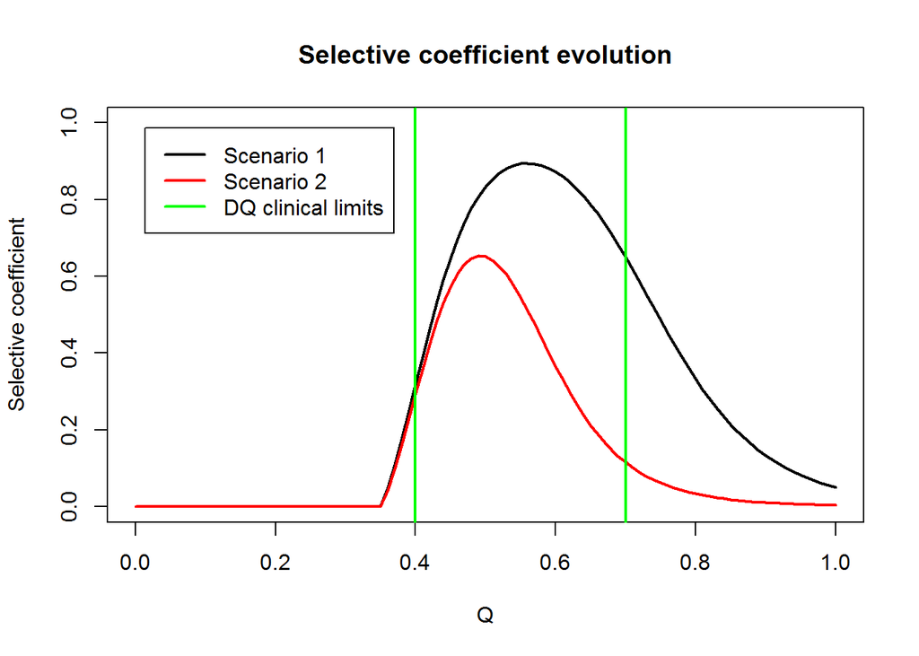

Here, we will consider two basic scenarios, anticipated by $Troy Day et al.$ In the first one, the selective coefficient is lowest for the lowest used drug concentration, i.e. the optimal strategy for preventing resistant selection corresponds to the lowest drug concentration (or drug quantity in our simplified model). In the second one it is the oposite : the selective coefficient is lowest for the highest value of drug concentration in the selection window.

### The outcome of selection

The outcome of selection will then depend on the product of selective coefficient and mutation rate as following :

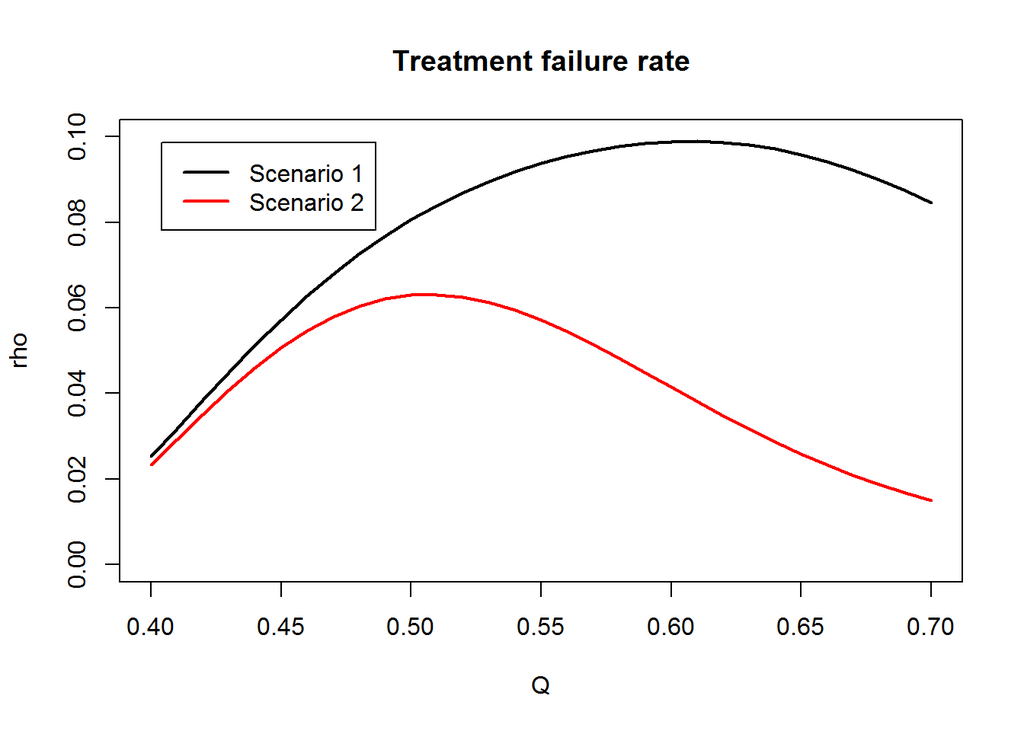

For each value of $Q$, the treatment failure rate $\rho$ will therefore take a different value in the model.

### The proportion of treated patients

In order to exploit, to what extent the different combinations of $\varepsilon$ and $Q$ can influence the model, the $AMU$ is fixed at certain value for a given series of simulations. The $AMU$ is fixed as well as a range of $Q$, the $\varepsilon$ is therefore determined for each value of $Q$:

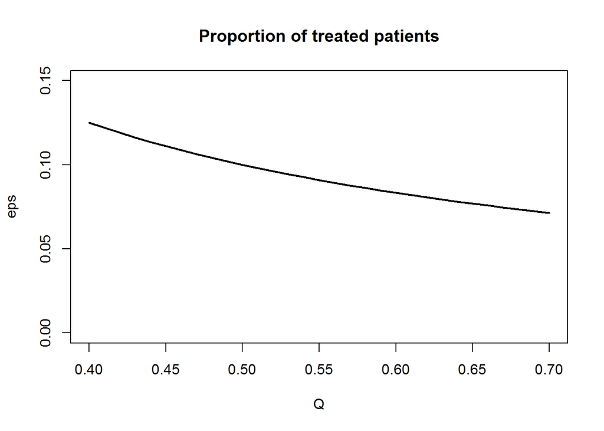

### Impact of possible D-$\varepsilon$ combinations on steady-states

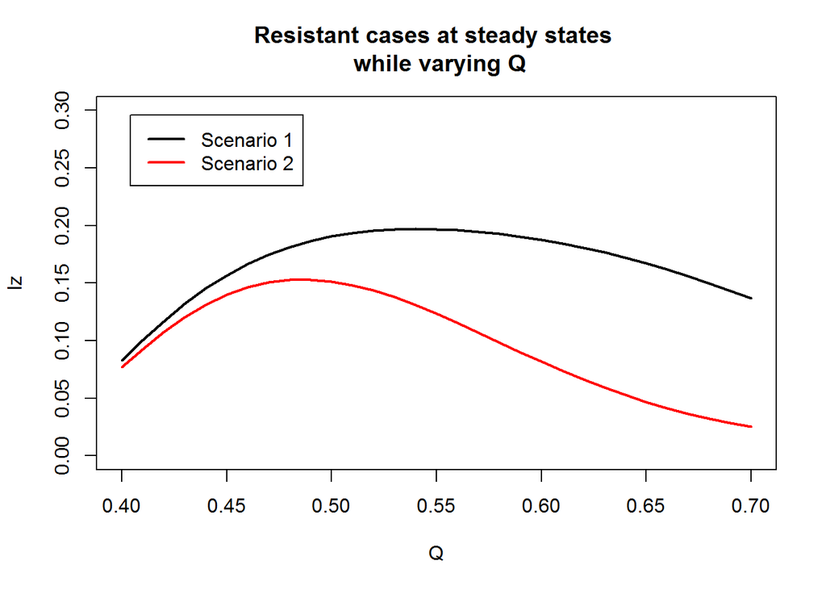

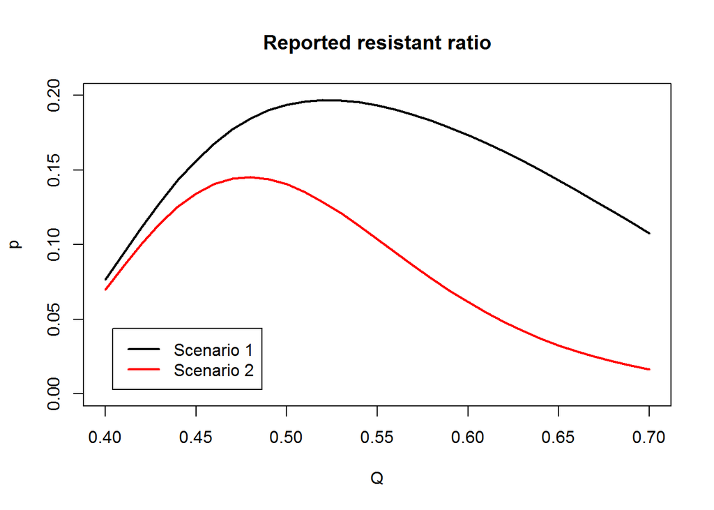

The combination of $Q$ and $\varepsilon$ has a big impact on the steady states.

In the first scenario, the maximum reached $I_z$ at steady state is twice as high as the minimum, while in the second one 5 times.

Interestingly, the same form of the curve as that of treatment failure rate is observed in both plots, though the maximum are switched to the left (A analyser plus tard). For increased values of $Q$ the values of $P$ are lower, which can be linked to the $\varepsilon$ that is decreasing with increasing drug combination and therefore the susceptible cases are cleansed at lower rate.

Meanwhile, the impact of global burden of disease shows a very little of difference (around 25%) for different combinations:

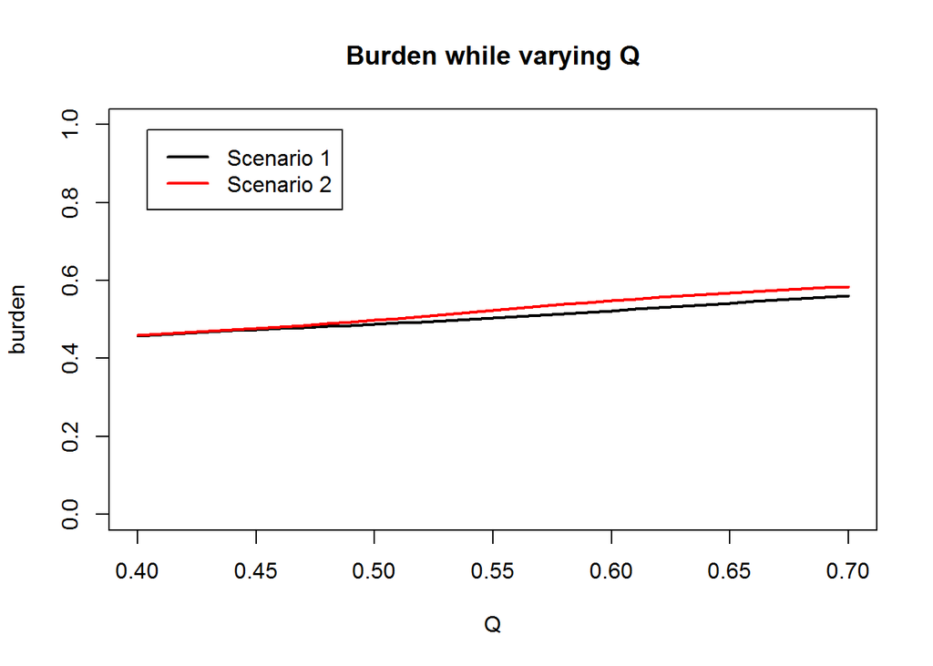

The burden of the disease increases with the drug quantity which is once again due to the lower recover rate of sensitive cases linked to lower values of $\varepsilon$.

### Varying $AMU$

In this part, exactly the same series of simulations are performed and compared for increasing values of $AMU$.

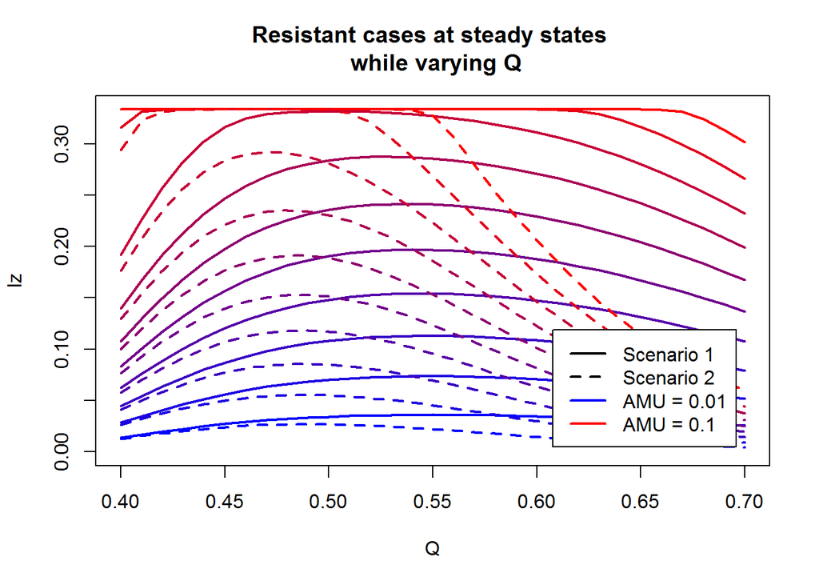

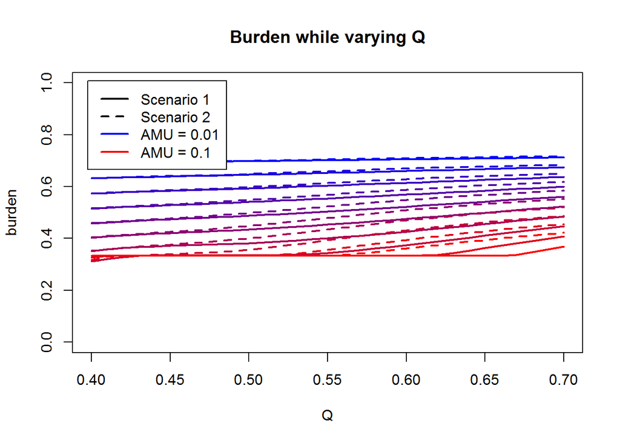

In consequence, the span of $I_z$ and $P$ for can be very large for higher values of $AMU$ :

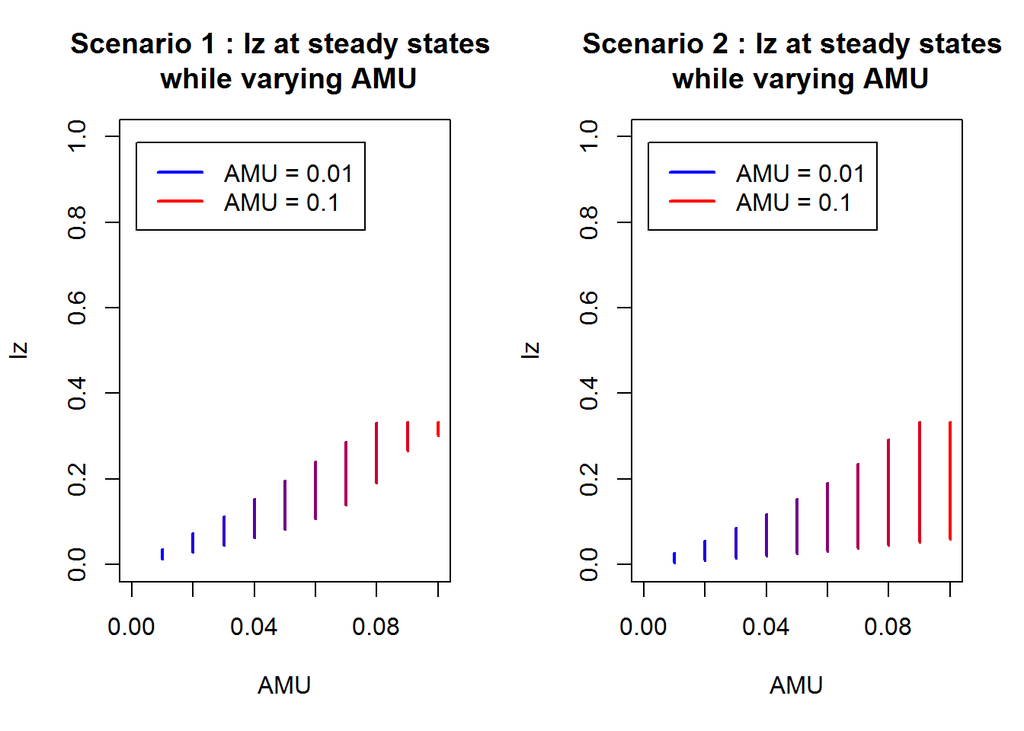

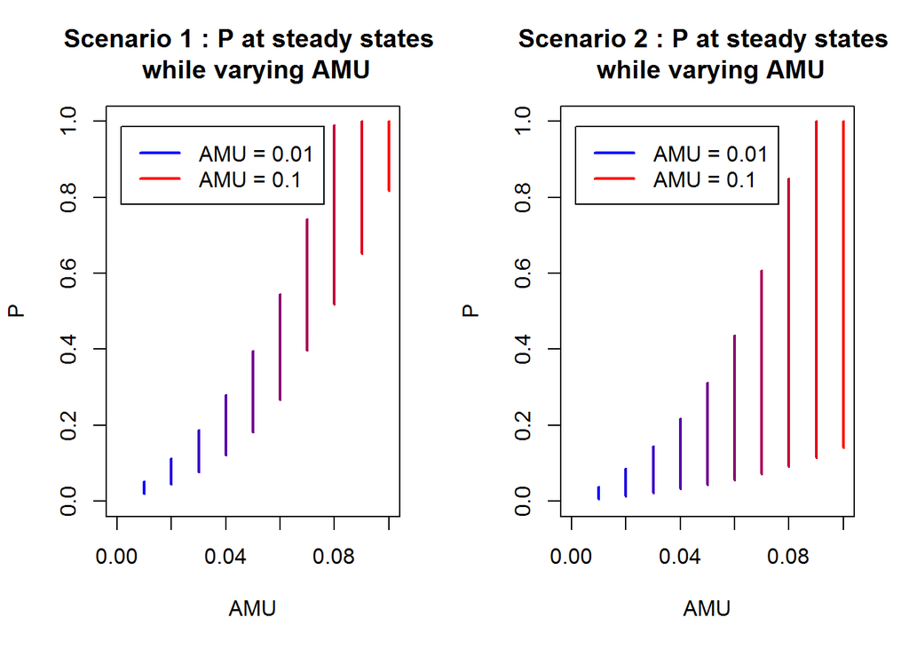

### Variations of AMU and Anti-honeymoon period

We then perform an analysis of the dynamics of the model following an abrupt change in one of the components of AMU ($\varepsilon$ or $Q$), the other one remaining stable. Once again, an anti-honeymoon period over 100 steps is observed when suddenly decreasing $\varepsilon$. We can therefore conclude, in cohesion with precedent observations, that $\varepsilon$ is responsible for this phenomenon while changing abruptly and not $Q$.

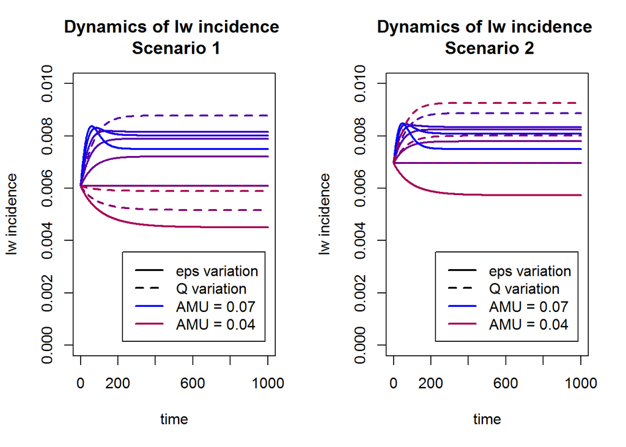

# Model with an impact of E

In this part, we consider that the absolute quantity of consumed antibiotics, $E$, has an impact on epidemiological dynamics through passive consumption via water and thus passive immunization. The new model is defined by following equations:

$$\begin{aligned}
\frac{dS}{dt} &=- \beta_w I_wS - \beta_z I_z S + \gamma I_z + \gamma(1 - \epsilon)I_w + \gamma ` \epsilon I_w \\
\frac{dI_w}{dt} &=\beta_w I_wS + (1-\epsilon)\beta_wI_wI_z - \gamma(1 - \epsilon)I_w - \gamma ` \epsilon I_w - \epsilon\beta_zI_zI_w - \rho\epsilon I_w - \rho'I_w \\
\frac{dI_z}{dt} &=\beta_z I_zS + \epsilon\beta_zI_zI_w + \rho\epsilon I_w + \rho'I_w - \gamma I_z - (1-\epsilon)\beta_wI_wI_z \\
\end{aligned}$$

where :
$$\begin{aligned}
\beta_w &= \beta_{w_0} - a*E\\
\beta_z &= \beta_{z_0} + b*E\\
\rho' &= c*E\\
\end{aligned}$$

$\beta_w$ decreases with $E$ : this relationship is based on these assumptions:

1. as $E$ increases, antibiotics spread into environment and people will consume them passively (antibiotics are for exemple diluted in water)
2. the more people consume antibitics passively, the less probable will be an infectious contact, due to the fact that the body of susceptible person will be passively immunized and less prone to infection

## Parameters

[output not shown]

There are different scenarios considering $E$ that depend on the efficiency of AMR detection :

| E expression | Scenario |
| --- | --- |
| $E = I_w*Q*\varepsilon$ | Ideal AMR detection |
| $E = (I_w+I_z)*Q*\varepsilon$ | No AMR detection |
| $E = I_w*Q*\varepsilon + A$ | Environmental use + Ideal AMR detection |
| $E = (I_w+I_z)*Q*\varepsilon + A$ | Environmental use + No AMR detection |
| $E = (I_w+a*I_z)*Q*\varepsilon + A$ | General expression |

## Basic model without detailed AMU

First, we consider that $Q$=1, $i.e.$ we do not detail $AMU$ as in the previous section. The following steady-states correspond to the “No AMR detection” scenario.

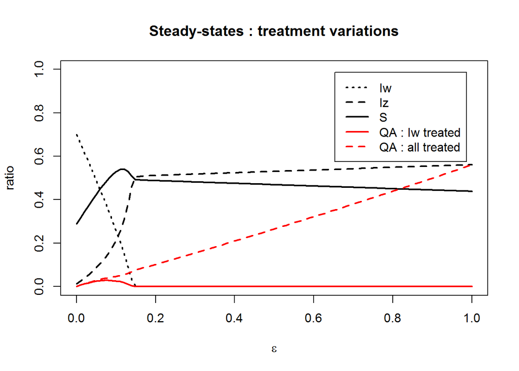

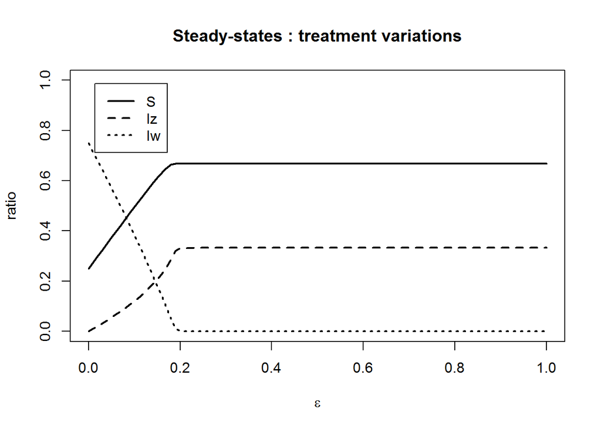

## Model with detailed AMU

In this model we consider that $AMU = Q*\varepsilon$. As in the previous section, we consider that the intrahost selection and mutation rate depend on the quantity of consumed ATB ($Q$).

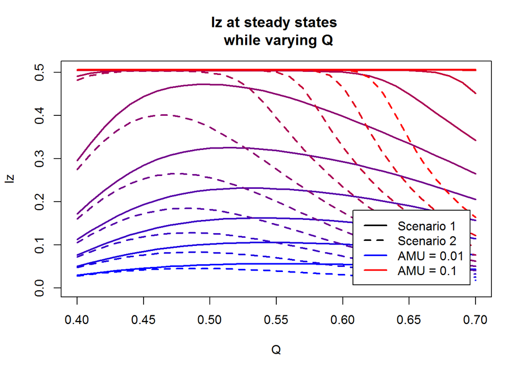

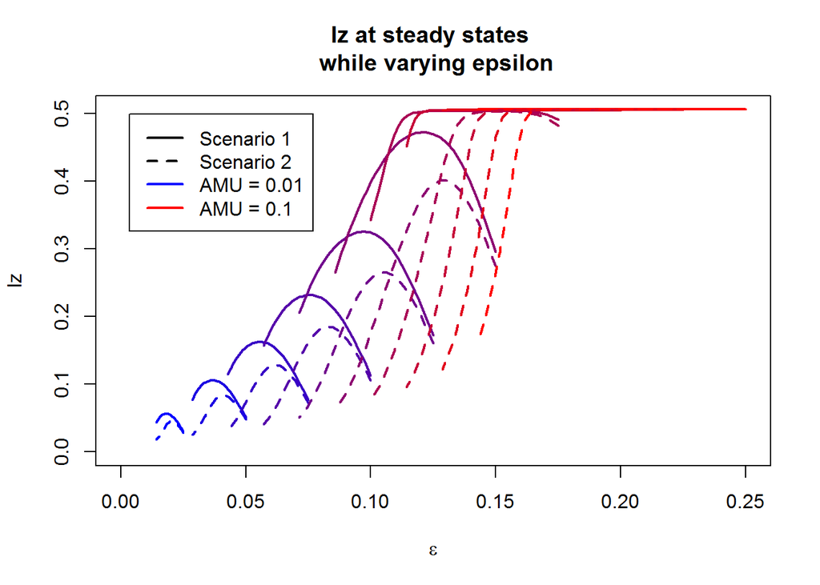

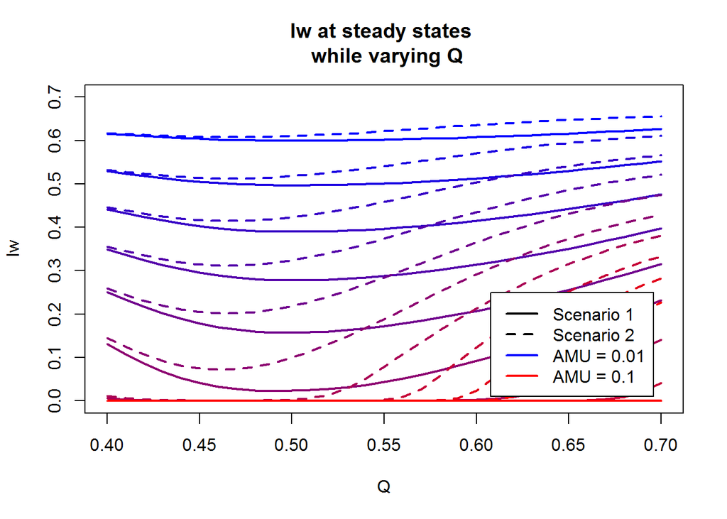

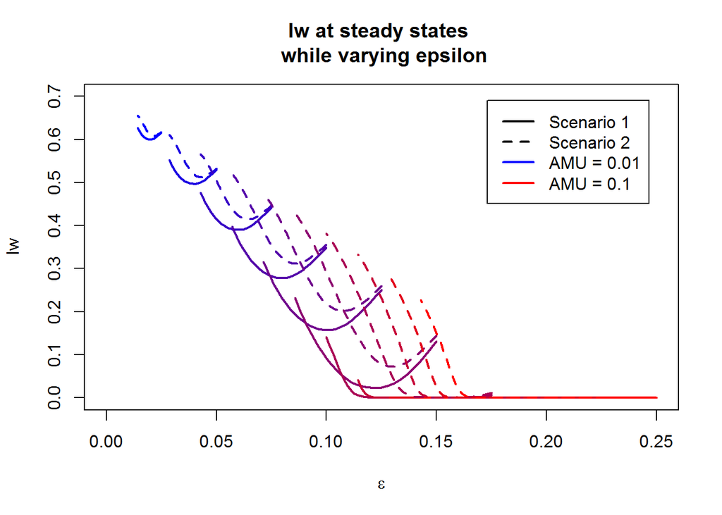

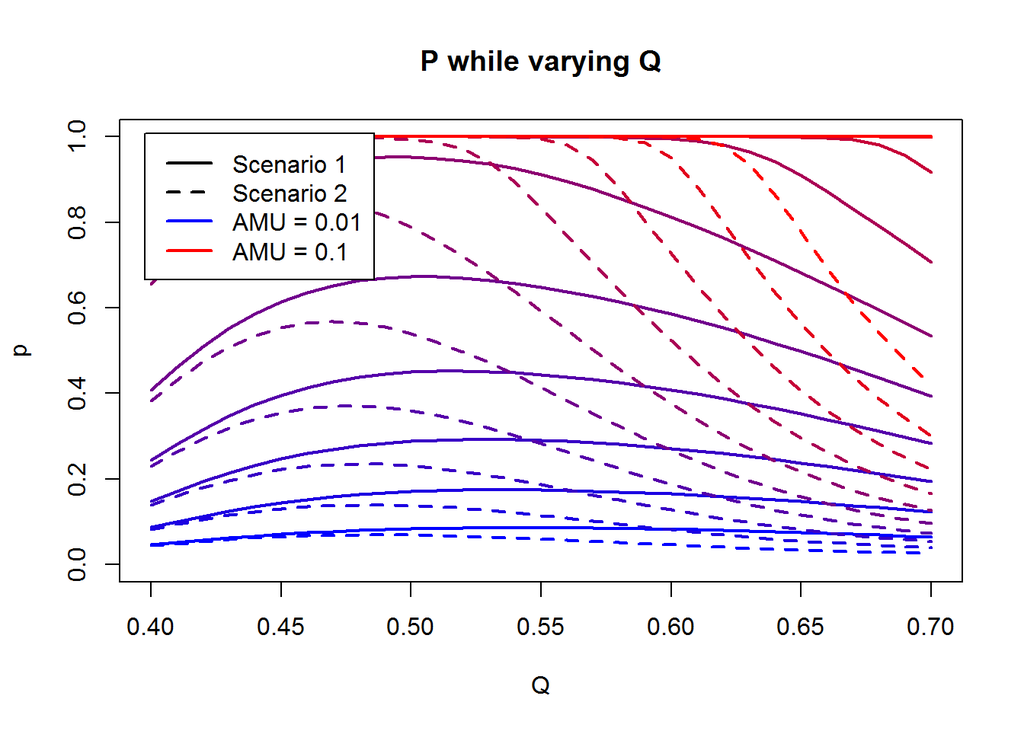

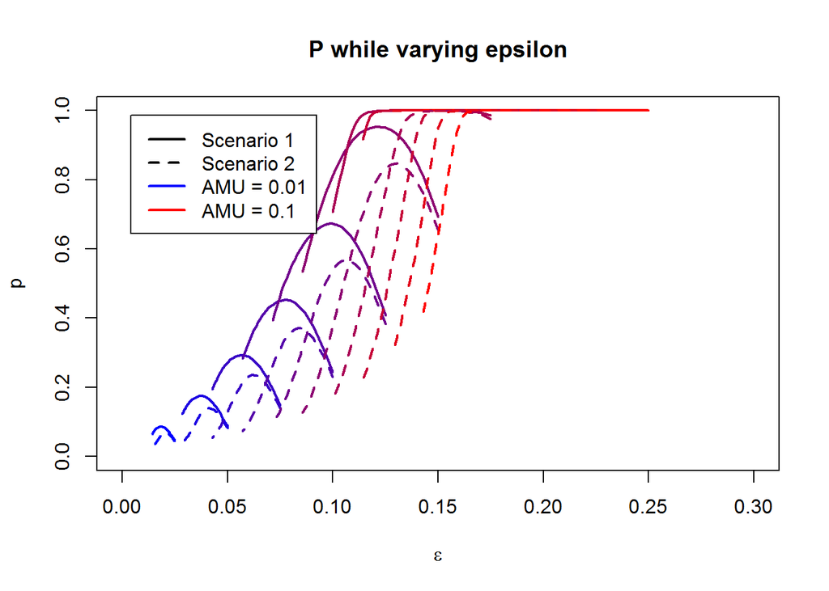

In consequence, the span of $I_z$ and $P$ for can be very large for higher values of $AMU$ :

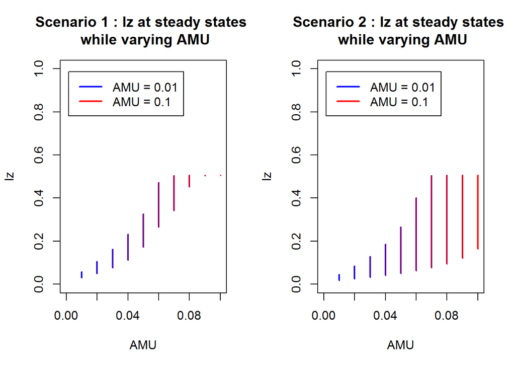

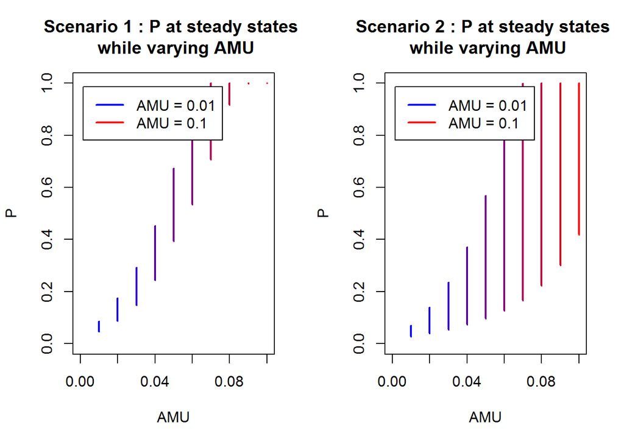

A very large span of $I_z$ and $P$ values can correspond to the same $AMU$. Though our model is very general, it demonstrates that the $AMU$ measure cannot be therefore suitable for statistical studies of $AMR$.

### Variations of AMU and Anti-honeymoon period

Once again, the anti-honeymoon period can be observed when decrasing abruptly $\varepsilon$.

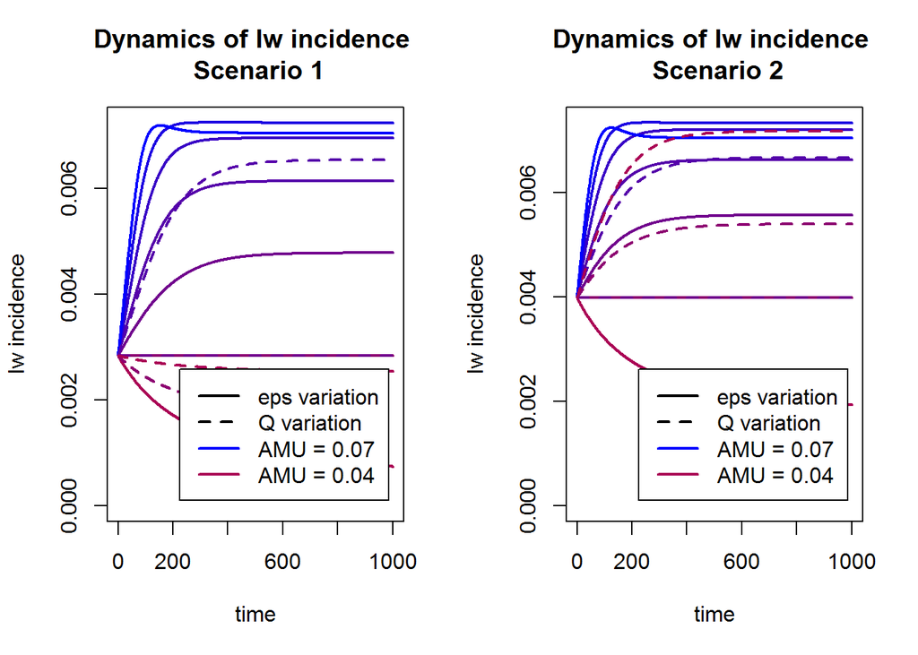

# Conclusion

We have used SI models in order to inspect what kind of problems one may face while relating $AMR$ with $AMU$. In order to keep our conclusions general, the model is general as well and parameters that would be specific to one disease are not implemented. Although the values of parameters are arbitrary and therefore it does not include a simple time dimension (the ‘steps’ can though be assimilated to one to several days), our models remain realistic as only realistic relationships between state variables are taken into account.

This study shows three important arguments, for which relating $AMR$ with $AMU$ is not optimal and may lead to false conclusions :

1. Inertia

When relating $AMU$ to $AMR$ the basic assumption is that all the reporting hospitals are at a steady state. Yet such a premise is difficult to justify as the patterns in consumption may change seasonally (!!see about that). In our simplest model, we have demonstrated that a change, and its speed, in proportion of treated patients may have a serious impact on $AMR$ and the relationship may become over- or underestimated. Furthermore, in contrast with some previous studies, our model showed, that the steady-states are reached sooner when decreasing $AMU$ than while increasing it (which might be due to a lack of evolutive component of resistant strain in our model).

2. Anti-honeymoon period

While decreasing suddenly the proportion of treated patients, an outburst of new sensitive cases can take place. The steady state for the given parameters is a way lower under the vaues reached during the outburst. This phenomenon arises from an interplay of infected cases’ redistribution towards sensitive ones, prolongation of average duration of disease and consequent accumulation of sensitive cases.

Such a phenomenon, called here anti-honeymoon period in reference to honeymoon period described in post-vaccination dynamics, may cause an underestimation in incidence-based report on resistance.

3. Syntheticity of $AMU$

The $AMU$ reported as defined-daily-doses per patient or per occupied bed is therefore a product of the proportion of treated patients between all patients $\varepsilon$ and the quantity of drug or number of doses per patient per day $Q$.

We have considered two scenarios with two hypothetical optimal strategies to prevent the therapeutic failure causing an emergence of $AMR$ (described by $Day$ $et$ $al.$) while the clearance is considered stable. First scenario’s optimal strategy being the lowest $Q$ and the second one’s being the highest $Q$ in safety window, both showed a large span of $AMR$ and $P$ within the same $AMU$.